# Capstone Milestone Report

Warren T Ferrell Jewell

November 16, 2016

## About the Data

Data is provided by swiftkey in conjunction with Coursera Data Science CAPSTONE presented by Johns Hopkins University. The three English datasets were used for this analysis.

- Twitter is 159 MB with 2360148 lines
- Blogs is 200 MB with 899288 lines
- News is 196 MB with 77259 lines

## Loading Data

Data is too big to work with all at once so a subset that is equal to about 10 MB was used. Randomly selecting lines from the data. The tm package is slow to manipulate whole corpora (collection of text data) so some data cleaning was reformed during data loading. These inclue removing non english characters, double punctuation, and twitter hashtags. A space was also added before and after each punctuation mark so they can be treated as part of an n-gram.

## Basic look at data

To examine data we generate a term document matrix (TDM) from each corpus after removing whitespace, and changing letters to all lower case. Punctuation and stopwords are left in because they could heavily affect text prediction. We ignore all terms that only occur once.

```r
transformations <- list( content_transformer(tolower), stripWhitespace )
corpora <- lapply(corpora, function(x)
            tm_map(x, tm_reduce, tmFuns = transformations))
tdm <- lapply(corpora, function(x) tm::TermDocumentMatrix(x, list(global = list(c(2,Inf)))))
tdm
```

```
## $twit
## <<TermDocumentMatrix (terms: 57900, documents: 145421)>>
## Non-/sparse entries: 1318011/8418557889
## Sparsity           : 100%
## Maximal term length: 86
## Weighting          : term frequency (tf)
##
## $blog
## <<TermDocumentMatrix (terms: 44119, documents: 24193)>>
## Non-/sparse entries: 627699/1066743268
## Sparsity           : 100%
## Maximal term length: 29
## Weighting          : term frequency (tf)
##
## $news
## <<TermDocumentMatrix (terms: 11551, documents: 1995)>>
## Non-/sparse entries: 48879/22995366
## Sparsity           : 100%
## Maximal term length: 21
## Weighting          : term frequency (tf)
```

## Cleaning Data

We see that each corpus still has thousands of terms and each term is extremely sparse. A term Frequency vector cannot be generated on most computers by R’s default as.matrix function (can’t allocate a 62 GB vector). Interestingly, news posts have the best convergence with only 11551 terms but its sparsity (appears in few documents) is still approximately 100%. This is due to a large number of terms that still only occur a few number of times - e.g. 11960 terms only appear once in the twitter corpora. To fix this we remove all terms with sparsity less than 0.999 from the TDM. This number was found experimentally. Sparsity of .99 produced only 128 terms from twitter. An average native speaker has a vocabulary of 20,000 - 35,000 so a 128 term model would likely not be able to predict even 1% of any 2 - grams they might devise. 0.999 produced 1132, 3172, and 4830 terms respectively

```r
tdm.cln <- lapply(tdm, function(x) tm::removeSparseTerms(x, 0.999))
tdm.cln
```

```
## $twit
## <<TermDocumentMatrix (terms: 1132, documents: 145421)>>
## Non-/sparse entries: 950143/163666429
## Sparsity           : 99%
## Maximal term length: 15
## Weighting          : term frequency (tf)
##
## $blog
## <<TermDocumentMatrix (terms: 3172, documents: 24193)>>
## Non-/sparse entries: 494667/76245529
## Sparsity           : 99%
## Maximal term length: 14
## Weighting          : term frequency (tf)
##
## $news
## <<TermDocumentMatrix (terms: 4830, documents: 1995)>>
## Non-/sparse entries: 42158/9593692
## Sparsity           : 100%
## Maximal term length: 15
## Weighting          : term frequency (tf)
```

```r
termFreq <- lapply(tdm.cln, function(x) as.matrix(slam::rollup(x, 2, FUN = sum)))
termFreq <- lapply( termFreq, function(x) x[order(x, decreasing = TRUE), ])
lapply(termFreq, head)
```

```
## $twit
##   the   you   and   for  that  with
## 57161 36930 27036 23851 16929 10593
##
## $blog
##   the   and  that   for   you  with
## 50278 29335 13019  9811  8838  7483
##
## $news
##  the  and that  for with said
## 3986 1828  785  718  516  491
```

```r
lapply(termFreq, tail)
```

```
## $twit
##   homework     agreed commercial     signed    showing    telling
##        148        147        147        147        146        146
##
## $blog
##    split sticking   switch  travels    trick      yay
##       25       25       25       25       25       25
##
## $news
## worldwide    yankee   zealand    zombie       zoo  zydrunas
##         2         2         2         2         2         2
```

## Exploring Data Terms

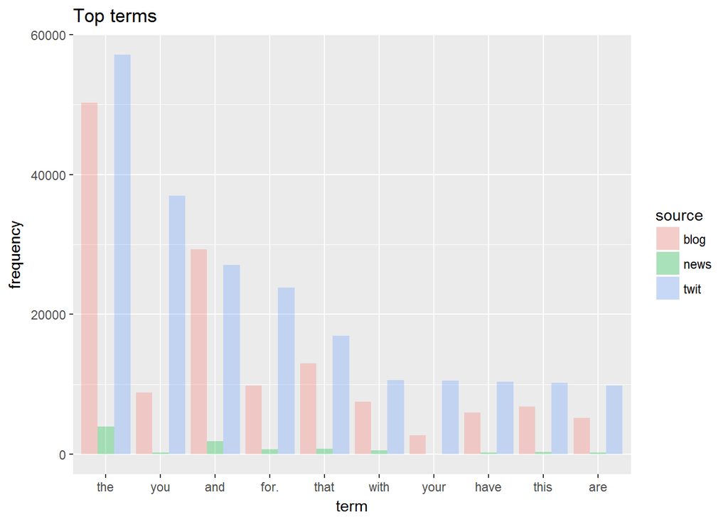

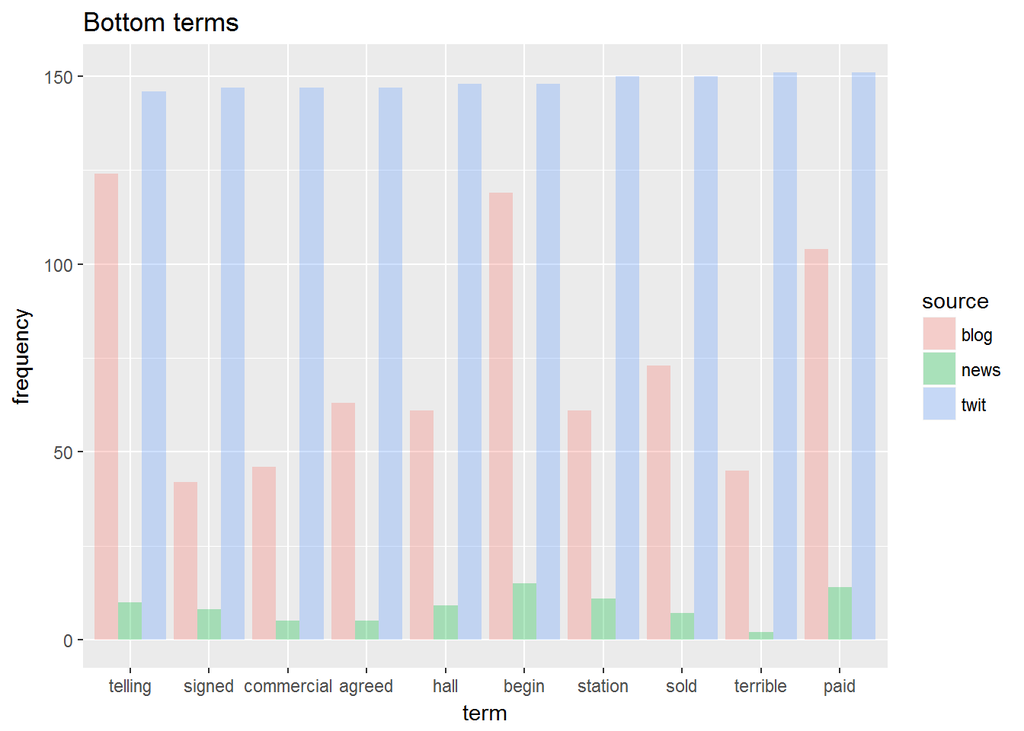

## Remove infrequent terms from corpora

Using the cleaned tdm we come up with a list of terms to keep from each corpus. Removing all words we don’t want would be far more computationally expensive and the tm package provides a removeWords function but it works by forming a very large regex expression. A regex that long is not supported by the compiler so we would need to use a loop to remove each term from the corpurs ourself.

```r
commonTerms <- lapply(tdm.cln, function(x) x$dimnames$Terms)
for (i in seq_along(corpora)) {    # no easy pass by reference in R
    takeCommonTerms <- function(x) {
        s <- strsplit(x, split = " ")
        y <- c()
        for(word in unlist(s)) {
            if(word %in% commonTerms[[i]])
                y <- paste(y, word, sep = " ")
        }
        return(y)
    }
    corpora[[i]] <- tm_map(corpora[[i]], content_transformer(takeCommonTerms))
}
```

## N-grams

Now that we have the most common terms we create all the potenial 2-4 grams that we will attempt to predict.

```
## $twit
## <<TermDocumentMatrix (terms: 1345500, documents: 145421)>>
## Non-/sparse entries: 2178324/195661777176
## Sparsity           : 100%
## Maximal term length: 53
## Weighting          : term frequency (tf)
##
## $blog
## <<TermDocumentMatrix (terms: 1309027, documents: 24193)>>
## Non-/sparse entries: 1738466/31667551745
## Sparsity           : 100%
## Maximal term length: 58
## Weighting          : term frequency (tf)
##
## $news
## <<TermDocumentMatrix (terms: 124011, documents: 1995)>>
## Non-/sparse entries: 135463/247266482
## Sparsity           : 100%
## Maximal term length: 62
## Weighting          : term frequency (tf)
```

```
## $twit
##           c("for", "the")        c("thanks", "for")
##                      4876                      2771
##         c("thank", "you") c("thanks", "for", "the")
##                      2080                      1556
##           c("are", "you")           c("and", "the")
##                      1552                      1519
##
## $blog
##  c("and", "the")  c("for", "the")  c("the", "the") c("with", "the")
##             2419             1731             1431             1276
##  c("the", "and") c("from", "the")
##             1256             1074
##
## $news
##   c("for", "the")   c("and", "the")  c("with", "the")  c("that", "the")
##               143               130               104                89
##  c("from", "the") c("more", "than")
##                79                60
```

```
## $twit
##   c("youtube", "you", "guys", "have")
##                                     1
##            c("youtube", "you", "not")
##                                     1
##   c("youtube", "you", "not", "going")
##                                     1
##                  c("youtube", "your")
##                                     1
##           c("youtube", "your", "and")
##                                     1
## c("youtube", "your", "and", "please")
##                                     1
##
## $blog
##       c("zone", "will", "held", "fair")
##                                       1
##               c("zone", "will", "host")
##                                       1
##        c("zone", "will", "host", "the")
##                                       1
##                    c("zone", "writing")
##                                       1
##          c("zone", "writing", "almost")
##                                       1
## c("zone", "writing", "almost", "about")
##                                       1
##
## $news
##                      c("zoo", "which", "also")
##                                              1
##        c("zoo", "which", "also", "apparently")
##                                              1
##            c("zydrunas", "ilgauskas", "front")
##                                              1
##     c("zydrunas", "ilgauskas", "front", "the")
##                                              1
##         c("zydrunas", "ilgauskas", "williams")
##                                              1
## c("zydrunas", "ilgauskas", "williams", "west")
##                                              1
```

## Clean Ngrams

Too many grams to deal with so we must remove sparse ngrams. Then look at the bottom ngrams to see if they are sensicle.

```r
gdm.cln <- gdm
gdm.cln <- lapply(gdm, function(x) tm::removeSparseTerms(x, 0.999))
gramFreq <- lapply(gdm.cln, function(x) as.matrix(slam::rollup(x, 2, FUN = sum)))
gramFreq <- lapply(gramFreq, function(x) x[order(x, decreasing = TRUE), ])
gdm.cln
```

```
## $twit
## <<TermDocumentMatrix (terms: 438, documents: 145421)>>
## Non-/sparse entries: 146519/63547879
## Sparsity           : 100%
## Maximal term length: 35
## Weighting          : term frequency (tf)
##
## $blog
## <<TermDocumentMatrix (terms: 2396, documents: 24193)>>
## Non-/sparse entries: 154013/57812415
## Sparsity           : 100%
## Maximal term length: 32
## Weighting          : term frequency (tf)
##
## $news
## <<TermDocumentMatrix (terms: 5060, documents: 1995)>>
## Non-/sparse entries: 16512/10078188
## Sparsity           : 100%
## Maximal term length: 46
## Weighting          : term frequency (tf)
```

```r
lapply(gramFreq, tail)
```

```
## $twit
##  c("that", "they")   c("this", "one")    c("was", "and")
##                149                149                149
## c("about", "this")   c("wish", "was")   c("your", "the")
##                148                148                147
##
## $blog
##  c("with", "which")   c("women", "who") c("years", "later")
##                  25                  25                  25
##    c("you", "also")    c("you", "been")    c("you", "come")
##                  25                  25                  25
##
## $news
##           c("you", "with")           c("you", "work")
##                          2                          2
##           c("you", "your")          c("young", "man")
##                          2                          2
##       c("young", "people") c("zydrunas", "ilgauskas")
##                          2                          2
```

## Top Ngrams

Graph of top and bottom grams

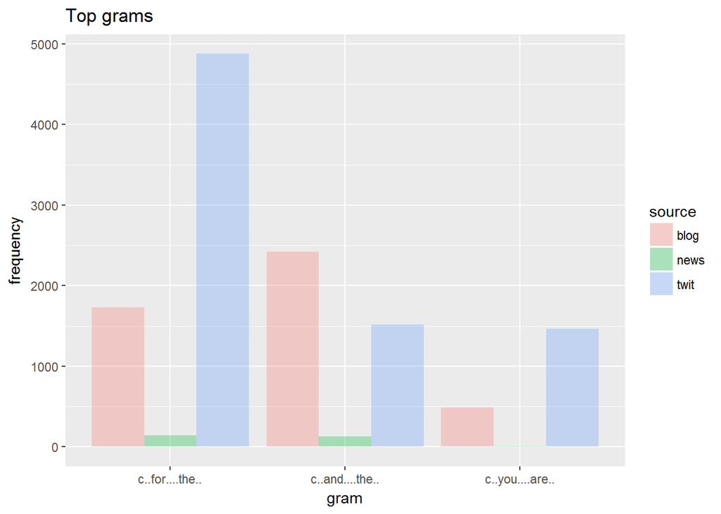

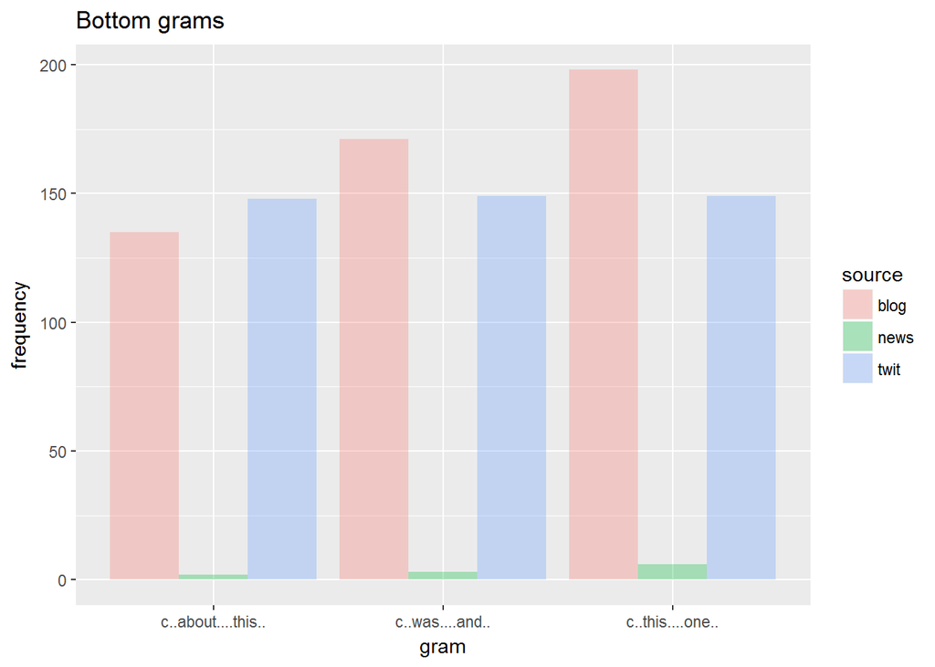

## Model

Generate models based on the created Ngrams. Use a list of linked lists (essentially a hash table) to dramatically reduce the size of the model. Each term has a list that points to terms that have been seen following that term. The final term in the gram is stored in the list with a frequency variable that is used to rank which is the most likely gram during prediction.

```r
nGramModel.create <- function(gramFreq) {
    model <- structure(list(), class = "nGramModel")
    for (i in seq_along(gramFreq)) {
        gram <- eval(parse(text = names(gramFreq[i])))
        freq <- gramFreq[[i]]
        recurse <- function(model, gram, freq) {
            term = gram[[1]]
            if( length(gram) == 1 ) {
                model[[term]] <- list("gfreq" = freq)
                return( model )
            }
            else {
                model[[term]] <- recurse(model[[term]], gram[-1], freq)
                return( model )
            }
        }
        model  <- recurse(model, gram, freq)
    }
    return ( model )
}
gramModel <- lapply(gramFreq, function(x) nGramModel.create(x))
save(gramModel, file = paste0(object.size(gramModel), "gramModel.RData"))
```

## Predict

```
## $twit
## [1] "the"  "and"  "best"
##
## $blog
## [1] "the"  "and"  "same"
##
## $news
## [1] "first" "state" "the"
```

```
## $twit
## [1] "the"       "following" ""
##
## $blog
## [1] "" "" NA
##
## $news
## [1] "the"  "and"  "this"
```

```
## $twit
## [1] "are"  "have" "can"
##
## $blog
## [1] "can"  "are"  "have"
##
## $news
## [1] "can"  "have" "don"
```

## Thoughts

Need to remove grams that resulted from removing uncommon terms from the dataset.

## references

https://eight2late.wordpress.com/2015/05/27/a-gentle-introduction-to-text-mining-using-r/

http://stackoverflow.com/questions/13614399/how-can-i-use-attr-with-lapply

http://stackoverflow.com/questions/32997201/how-to-store-sparsity-and-maximum-term-length-of-a-term-document-matrix-from-tm

http://www.economist.com/blogs/johnson/2013/05/vocabulary-size